# A Reproducible Workflow exercise

Environment and Climate Change Canada, inSileco

2021-03-01

# Section 1 title

## Subsection 1 title

*Lorem* **ipsum** *dolor* sit amet, consectetur adipiscing elit. Nulla eget ipsum a nulla maximus ornare. Nunc ut nibh orci. Phasellus lacinia velit sed tincidunt euismod. Morbi euismod, lectus et consectetur tristique, urna eros facilisis magna, faucibus condimentum leo dui a enim. Praesent massa velit, egestas et eros eget, ornare tincidunt nisl. Vestibulum mattis enim a enim mattis iaculis. Etiam ipsum tortor, vehicula pretium consequat at, pharetra non mauris. Nam ac facilisis libero. Donec ut arcu gravida, pellentesque eros in, tempor mi.

Numbered list of numbers

1. one
2. two
3. three

> A man who dares to waste one hour of time has not discovered the value of life.

| species | island | bill_length_mm | bill_depth_mm | flipper_length_mm | body_mass_g | sex | year |
| --- | --- | --- | --- | --- | --- | --- | --- |
| Adelie | Torgersen | 39.1 | 18.7 | 181 | 3750 | male | 2007 |
| Adelie | Torgersen | 39.5 | 17.4 | 186 | 3800 | female | 2007 |
| Adelie | Torgersen | 40.3 | 18.0 | 195 | 3250 | female | 2007 |
| Adelie | Torgersen | NA | NA | NA | NA | NA | 2007 |
| Adelie | Torgersen | 36.7 | 19.3 | 193 | 3450 | female | 2007 |
| Adelie | Torgersen | 39.3 | 20.6 | 190 | 3650 | male | 2007 |
| Adelie | Torgersen | 38.9 | 17.8 | 181 | 3625 | female | 2007 |
| Adelie | Torgersen | 39.2 | 19.6 | 195 | 4675 | male | 2007 |
| Adelie | Torgersen | 34.1 | 18.1 | 193 | 3475 | NA | 2007 |
| Adelie | Torgersen | 42.0 | 20.2 | 190 | 4250 | NA | 2007 |
| Adelie | Torgersen | 37.8 | 17.1 | 186 | 3300 | NA | 2007 |
| Adelie | Torgersen | 37.8 | 17.3 | 180 | 3700 | NA | 2007 |
| Adelie | Torgersen | 41.1 | 17.6 | 182 | 3200 | female | 2007 |
| Adelie | Torgersen | 38.6 | 21.2 | 191 | 3800 | male | 2007 |
| Adelie | Torgersen | 34.6 | 21.1 | 198 | 4400 | male | 2007 |
| Adelie | Torgersen | 36.6 | 17.8 | 185 | 3700 | female | 2007 |
| Adelie | Torgersen | 38.7 | 19.0 | 195 | 3450 | female | 2007 |
| Adelie | Torgersen | 42.5 | 20.7 | 197 | 4500 | male | 2007 |
| Adelie | Torgersen | 34.4 | 18.4 | 184 | 3325 | female | 2007 |
| Adelie | Torgersen | 46.0 | 21.5 | 194 | 4200 | male | 2007 |

## Subsection 2 title

The [penguins dataset](https://github.com/allisonhorst/palmerpenguins) contains data on 344 individuals, 3 species, and from 3 islands. Across individuals, the mean flipper length is 200.92 $mm$.

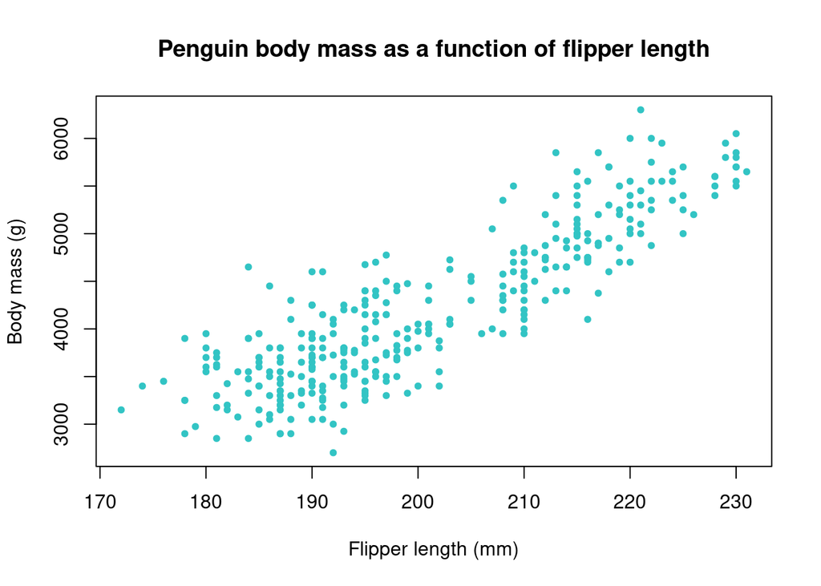

# Jacob

```
## [1] 2
```

# Katie Section

Petrels are **great**!

That’s all for now.

Or maybe not.

# Ana’s section

In this section we can learn about bill length differences between our three different penguin species.

To start, we will first take a look at this plot showing bill length per penguin species:

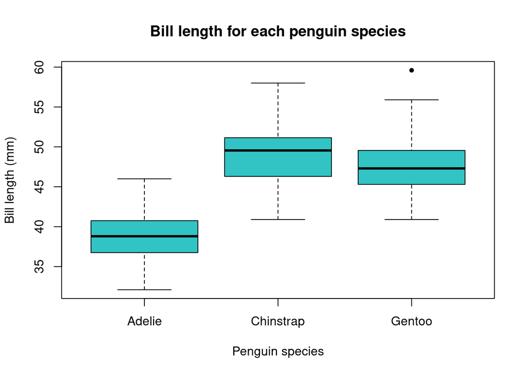

# Sarah

## Penguin Myths

They say penguins can’t fly. That’s not true.

**Proof that penguins can fly**

[figure not shown]

## Penguin flight variability by island

Penguins flight varies by island based on wing length. Penguins from Biscoe are the best at flying. Check out how long their wings are.

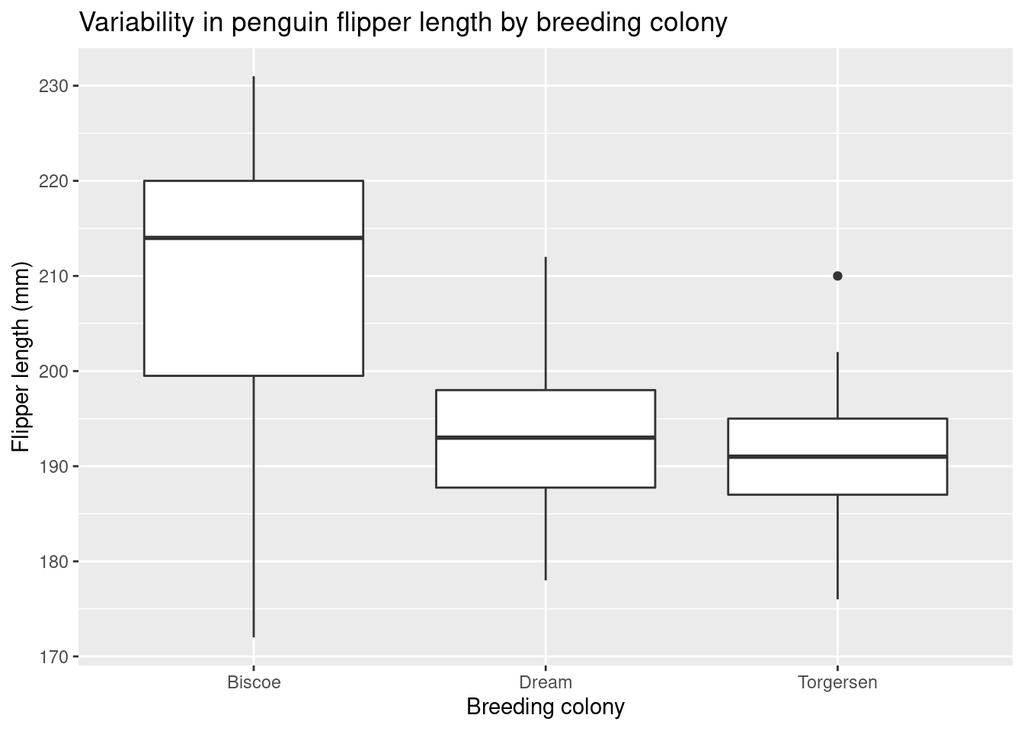

[^1]: Artwork by @allison_horst